# INLA 1

Lenin Rafael Riera Segura

Created: 12-04-2024. Last modified: 13-04-2024.

```css
body .main-container {
  max-width: 100% !important;
  width: 100% !important;
}
body {
  max-width: 100% !important;
}

body, td {
   font-size: 16px;
}
code.r{
  font-size: 14px;
}
pre {
  font-size: 14px
}
```

```r
knitr::opts_chunk$set(message = FALSE,
                      warning = FALSE,
                      fig.align = "center",
                      out.width = "100%"
                      )
set.seed(1982)
```

```r
library(INLA)
# Load the data
data(Seeds)

# Create a data frame
df <- data.frame(y = Seeds$r, Ntrials = Seeds$n, Seeds[, 3:5])

# explore the data
df |> head() |> knitr::kable(caption = "Data")
```

Data

| y | Ntrials | x1 | x2 | plate |
| --- | --- | --- | --- | --- |
| 10 | 39 | 0 | 0 | 1 |
| 23 | 62 | 0 | 0 | 2 |
| 23 | 81 | 0 | 0 | 3 |
| 26 | 51 | 0 | 0 | 4 |
| 17 | 39 | 0 | 0 | 5 |
| 5 | 6 | 0 | 1 | 6 |

## 0.1 Model specification

The model specification is

$$y_i\sim\text{Binomial}\left(N_i, p_i\right)\label{eq1}\tag{A}$$

$$p_i = \text{invlogit}(\eta_i) = \frac{\exp(\eta_i)}{1+\exp(\eta_i)} =
\frac{1}{1+\exp(-\eta_i)}\qquad \left(\text{i.e., }\eta_i =
\text{logit}(p_i) =\log\left(\frac{p_i}{1-p_i}\right)
\right)$$

$$\eta_i = \beta_0 + \beta_1x_{1i} + \beta_2x_{2i} +v_i$$

$$\beta_i \sim \text{N}(0, 1000)$$

$$v_i\sim\text{N}(0,\sigma^2)$$
$$\sigma\sim\text{Exp}(\lambda) \qquad \left(\text{i.e., }\pi(\sigma) =
\lambda e^{-\lambda\sigma}\right)$$

$$\lambda \text{ is such that } \pi(\sigma>1) =
0.01\qquad\left(\text{i.e., }0.01 = \pi(\sigma>1) = 1-
\pi(\sigma\leq1) = e^{-\lambda}\implies \lambda =
-\dfrac{\log(0.01)}{1}\approx4.6\right)\label{eq2}\tag{B}$$

Expressions from $\eqref{eq1}$ to $\eqref{eq2}$ define the model.

- $v_i$ are the random effects.
- $\pi(\sigma>1) = 0.01$ corresponds exactly to `list(theta = list(prior = "pc.prec", param = c(1,0.01)))`
- $x_{1i}$ corresponds to `x1`
- $x_{2i}$ corresponds to `x2`
- $v_i$ corresponds to `f()`
- `model = "iid"` tells `inla()` we are using random effects
- INLA does not deal with $\sigma^2$ but with $\tau = \sigma^{-2}$. Therefore, using the change of variable formula, we can see that $\pi(\tau) = \dfrac{\lambda}{2}\tau^{-3/2}e^{-\lambda \tau^{-1/2}}$. Of course, $\pi(\sigma) = \pi(\tau)\left|\dfrac{d\tau}{d\sigma}\right| = \lambda e^{-\lambda\sigma}$ and we define $x=\log(\tau)$, then $\pi(x) = \pi(\tau)\left|\dfrac{d\tau}{dx}\right| = \dfrac{\lambda}{2}\exp\left(-\dfrac{x}{2} - \lambda \exp\left(-\dfrac{x}{2}\right)\right)$
- variable `plate` contains the identity of each observations. That is, `plate = 1:nrow(df)`.

The `logit()` function is not referenced as `"logit"` in `control.family = list(control.link = list(model = "logit"))`. This `"logit"` is an option from INLA.

```r
logit <- function(p){log(p/(1-p))}
invlogit <- function(x){exp(x)/(1 + exp(x))}
```

```r
# call to inla
formula1 = y ~ x1 + x2 + f(plate,
                           model = "iid",
                           hyper = list(theta = list(prior = "pc.prec",
                                                     param = c(1,0.01))))
res1 = inla(formula = formula1,
            data = df,
            family = "binomial",
            Ntrials = Ntrials,
            control.family = list(control.link = list(model = "logit")),
            control.predictor = list(compute = TRUE, link = 1))
```

## 0.2 SUMMARY

Here we show how to read the summary

```r
#str(res1, 1)
summary(res1)
```

```
## Time used:
##     Pre = 0.397, Running = 0.146, Post = 0.0129, Total = 0.556
## Fixed effects:
##               mean    sd 0.025quant 0.5quant 0.975quant   mode kld
## (Intercept) -0.387 0.181     -0.739   -0.390     -0.017 -0.390   0
## x1          -0.360 0.231     -0.838   -0.353      0.076 -0.353   0
## x2           1.033 0.221      0.589    1.034      1.469  1.034   0
##
## Random effects:
##   Name     Model
##     plate IID model
##
## Model hyperparameters:
##                      mean    sd 0.025quant 0.5quant 0.975quant mode
## Precision for plate 19.78 32.61       2.96    10.55      84.93 6.06
##
## Marginal log-Likelihood:  -68.44
##  is computed
## Posterior summaries for the linear predictor and the fitted values are computed
## (Posterior marginals needs also 'control.compute=list(return.marginals.predictor=TRUE)')
```

```r
res1$summary.random$plate |> head() |> knitr::kable(format = "markdown", caption = "Summary for the random effects $v_i$. Keep in mind that each of the $v_i$ has a marginal posterior distribution")
```

Summary for the random effects $v_i$. Keep in mind that each of the $v_i$ has a marginal posterior distribution

| ID | mean | sd | 0.025quant | 0.5quant | 0.975quant | mode | kld |
| --- | --- | --- | --- | --- | --- | --- | --- |
| 1 | -0.3048721 | 0.2799166 | -0.9193182 | -0.2777253 | 0.1690210 | -0.1865575 | 1.8e-06 |
| 2 | -0.0859020 | 0.2322269 | -0.5734246 | -0.0753286 | 0.3594506 | -0.0374485 | 2.0e-07 |
| 3 | -0.3302243 | 0.2477873 | -0.8626285 | -0.3116612 | 0.0969325 | -0.2731560 | 1.2e-06 |
| 4 | 0.2247960 | 0.2451079 | -0.2194150 | 0.2075763 | 0.7478821 | 0.1644006 | 6.0e-07 |
| 5 | 0.0559880 | 0.2459762 | -0.4318956 | 0.0503295 | 0.5620318 | 0.0481712 | 2.0e-07 |
| 6 | 0.1082028 | 0.3233222 | -0.5018687 | 0.0848420 | 0.8176961 | 0.0357540 | 1.6e-06 |

```r
res1$summary.fitted.values |> head() |> knitr::kable(format = "markdown", caption = "Summary for the fitted values $p_i$. Keep in mind that each of the $p_i$ has a marginal posterior distribution")
```

Summary for the fitted values $p_i$. Keep in mind that each of the $p_i$ has a marginal posterior distribution

|  | mean | sd | 0.025quant | 0.5quant | 0.975quant | mode |
| --- | --- | --- | --- | --- | --- | --- |
| fitted.Predictor.01 | 0.3366889 | 0.0585931 | 0.2213399 | 0.3376110 | 0.4489894 | 0.3417846 |
| fitted.Predictor.02 | 0.3851974 | 0.0491712 | 0.2903126 | 0.3845966 | 0.4840581 | 0.3838758 |
| fitted.Predictor.03 | 0.3300258 | 0.0470660 | 0.2394590 | 0.3297445 | 0.4221690 | 0.3291542 |
| fitted.Predictor.04 | 0.4597624 | 0.0579002 | 0.3544738 | 0.4570429 | 0.5794843 | 0.4501588 |
| fitted.Predictor.05 | 0.4190117 | 0.0580471 | 0.3108036 | 0.4165443 | 0.5398322 | 0.4108377 |
| fitted.Predictor.06 | 0.6748795 | 0.0746330 | 0.5208799 | 0.6752715 | 0.8202450 | 0.6717140 |

```r
res1$summary.linear.predictor |> head() |> knitr::kable(format = "markdown", caption = "Summary for the linear predictors $\\eta_i$. Keep in mind that each of the $\\eta_i$ has a marginal posterior distribution")
```

Summary for the linear predictors $\eta_i$. Keep in mind that each of the $\eta_i$ has a marginal posterior distribution

|  | mean | sd | 0.025quant | 0.5quant | 0.975quant | mode | kld |
| --- | --- | --- | --- | --- | --- | --- | --- |
| Predictor.01 | -0.6900708 | 0.2694952 | -1.2578749 | -0.6739587 | -0.2047549 | -0.6301493 | 7e-07 |
| Predictor.02 | -0.4725909 | 0.2100299 | -0.8938664 | -0.4700832 | -0.0637893 | -0.4697858 | 1e-07 |
| Predictor.03 | -0.7160158 | 0.2160387 | -1.1556479 | -0.7093411 | -0.3138756 | -0.7088183 | 3e-07 |
| Predictor.04 | -0.1633028 | 0.2358491 | -0.5994313 | -0.1722530 | 0.3206569 | -0.2093543 | 3e-07 |
| Predictor.05 | -0.3313658 | 0.2414092 | -0.7963650 | -0.3369758 | 0.1596671 | -0.3380491 | 2e-07 |
| Predictor.06 | 0.7522349 | 0.3550639 | 0.0835682 | 0.7321252 | 1.5180083 | 0.6785053 | 1e-07 |

```r
data.frame(p = res1$summary.fitted.values$mean,
           eta = res1$summary.linear.predictor$mean,
           p.from.eta = invlogit(res1$summary.linear.predictor$mean),
           eta.from.p = logit(res1$summary.fitted.values$mean)) |>
  head() |>
  knitr::kable(format = "markdown", caption = "This shows that `res1$summary.fitted.values` corresponds to the variable ($p_i$) related to the linear predictor ($\\eta_i$) via the link function (`logit()`), and `res1$summary.linear.predictor` corresponds to the linear predictor ($\\eta_i$)")
```

This shows that `res1$summary.fitted.values` corresponds to the variable ($p_i$) related to the linear predictor ($\eta_i$) via the link function (`logit()`), and `res1$summary.linear.predictor` corresponds to the linear predictor ($\eta_i$)

| p | eta | p.from.eta | eta.from.p |
| --- | --- | --- | --- |
| 0.3366889 | -0.6900708 | 0.3340173 | -0.6780847 |
| 0.3851974 | -0.4725909 | 0.3840032 | -0.4675453 |
| 0.3300258 | -0.7160158 | 0.3282709 | -0.7080682 |
| 0.4597624 | -0.1633028 | 0.4592648 | -0.1612992 |
| 0.4190117 | -0.3313658 | 0.4179083 | -0.3268316 |
| 0.6748795 | 0.7522349 | 0.6796655 | 0.7303381 |

```r
# betas
res1$summary.fixed |> head() |> knitr::kable(format = "markdown", caption = "Summary for the fixed effects")
```

Summary for the fixed effects

|  | mean | sd | 0.025quant | 0.5quant | 0.975quant | mode | kld |
| --- | --- | --- | --- | --- | --- | --- | --- |
| (Intercept) | -0.3869998 | 0.1812750 | -0.7387980 | -0.3901860 | -0.0174494 | -0.3900842 | 0e+00 |
| x1 | -0.3598793 | 0.2306548 | -0.8379330 | -0.3525627 | 0.0760314 | -0.3529317 | 1e-07 |
| x2 | 1.0328605 | 0.2214282 | 0.5891784 | 1.0343051 | 1.4690756 | 1.0344034 | 0e+00 |

```r
# hyperparameters
rbind(res1$summary.hyperpar, res1$internal.summary.hyperpar, "exp(Log precision for plate)" = exp(res1$internal.summary.hyperpar)) |>
  knitr::kable(format = "markdown", caption = "Summary for the hyperparameters")
```

Summary for the hyperparameters

|  | mean | sd | 0.025quant | 0.5quant | 0.975quant | mode |
| --- | --- | --- | --- | --- | --- | --- |
| Precision for plate | 19.77638 | 32.6086272 | 2.962334 | 10.552319 | 84.934394 | 6.061487 |
| Log precision for plate | 2.45365 | 0.8231329 | 1.085977 | 2.356346 | 4.441879 | 2.167511 |
| exp(Log precision for plate) | 11.63073 | 2.2776242 | 2.962334 | 10.552319 | 84.934394 | 8.736507 |

This is how the output of `inla()` corresponds to our model specification.

- $p_i$ = `res1$summary.fitted.values` (just the summary, not the whole the marginal posterior)
- $\eta_i$ = `res1$summary.linear.predictor` (just the summary, not the whole the marginal posterior)
- $\beta_i$ = `res1$summary.fixed` (just the summary, not the whole the marginal posterior)
- $\tau$ = `res1$summary.hyperpar` (just the summary, not the whole the marginal posterior)

## 0.3 MARGINAL POSTERIOR

### 0.3.1 For the fixed effects

Let us get the marginal posterior for $\beta_1$. No transformation is needed in this case.

```r
marginal.posterior.beta1.few = res1$marginals.fixed$x1 # we just get a few
marginal.posterior.beta1.all = inla.tmarginal(fun = function(x) x, marginal = res1$marginals.fixed$x1) # we get more
# let us check
data.frame(mean.from.summary = res1$summary.fixed$mean[2],
           mean.from.marginal.posterior.few = mean(marginal.posterior.beta1.few[,1]),
           mean.from.marginal.posterior.all = mean(marginal.posterior.beta1.all[,1])) |> t() |>
  knitr::kable(format = "markdown", caption = "Checking that we are getting the marginal posterior correctly")
```

Checking that we are getting the marginal posterior correctly

| mean.from.summary | -0.3598793 |
| --- | --- |
| mean.from.marginal.posterior.few | -0.3670171 |
| mean.from.marginal.posterior.all | -0.3602326 |

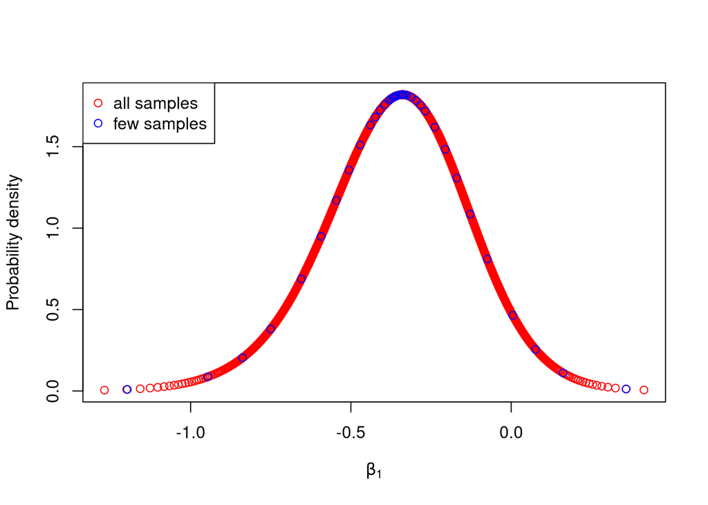

```r
plot(marginal.posterior.beta1.all, type = "p", xlab = expression(beta[1]), ylab = "Probability density", col = "red")
points(marginal.posterior.beta1.few, col = "blue")
legend("topleft", pch = 1, col = c("red", "blue"), legend = c("all samples", "few samples"))
```

To get the marginal posterior in a meaningful scale, we should change `fun` from `inla.tmarginal(fun, marginal)` as appropriate.

### 0.3.2 For the hyperparameters

Recall that `inla()` works with precision and that the internal parameters are in `log()` scale. So if we want the marginal posterior for $\sigma$ we need to use a transformation as appropriate.

Recall that $\tau = \sigma^{-2}$.

So if we let $\tau$ = `res1$marginals.hyperpar$Precision for plate`, then to get $\sigma = \tau^{-1/2}$, we need to use the transformation `fun(x) = x^(-1/2)`.

If we let $\log(\tau)$ = `res1$internal.marginals.hyperpar$Log precision for plate`, then to get $\sigma = \tau^{-1/2}$, we need to use the transformation `fun(x) = e^(-x/2)`.

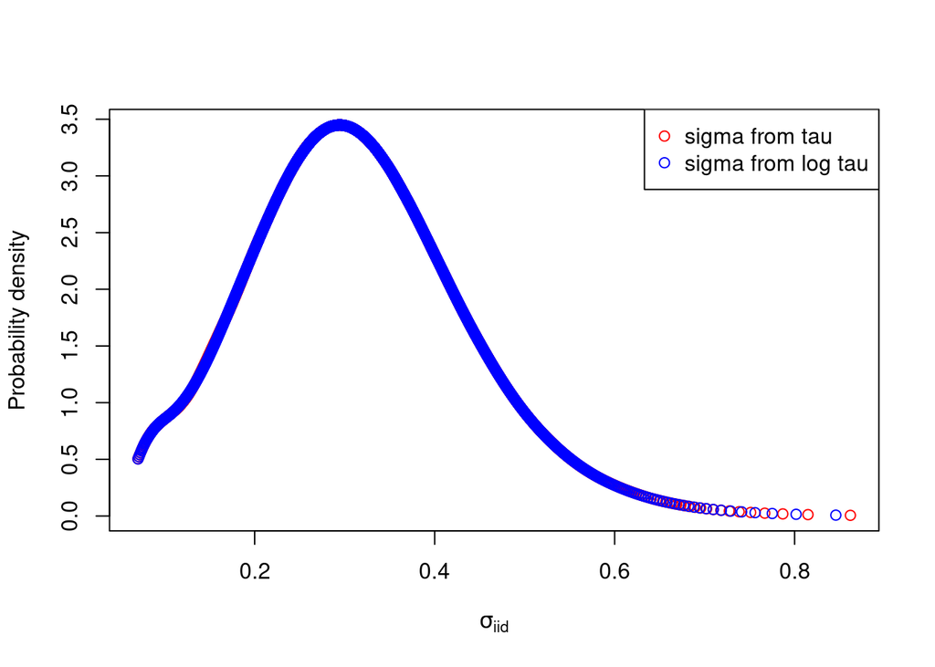

```r
# posterior of sigma
marginal.posterior.sigma.from.tau = inla.tmarginal(fun = function(x) x^(-0.5), marginal = res1$marginals.hyperpar$`Precision for plate`)
marginal.posterior.sigma.from.log.tau = inla.tmarginal(fun = function(x) exp(-x/2), marginal = res1$internal.marginals.hyperpar$`Log precision for plate`)

plot(marginal.posterior.sigma.from.tau, type = "p", xlab = expression(sigma[iid]), ylab = "Probability density", col = "red")
points(marginal.posterior.sigma.from.log.tau, col = "blue")
legend("topright", pch = 1, col = c("red", "blue"), legend = c("sigma from tau", "sigma from log tau"))
```

So if we let $\tau$ = `res1$marginals.hyperpar$Precision for plate`, then to get $\tau$, we need to use the transformation `fun(x) = x`.

If we let $\log(\tau)$ = `res1$internal.marginals.hyperpar$Log precision for plate`, then to get $\tau$, we need to use the transformation `fun(x) = e^x`.

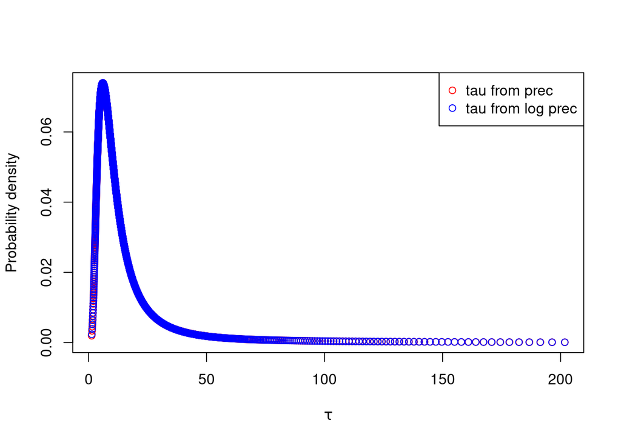

```r
# posterior of tau
marginal.posterior.tau.from.prec = inla.tmarginal(fun = function(x) x, marginal = res1$marginals.hyperpar$`Precision for plate`)
marginal.posterior.tau.from.log.prec = inla.tmarginal(fun = function(x) exp(x), marginal = res1$internal.marginals.hyperpar$`Log precision for plate`)

plot(marginal.posterior.tau.from.prec, type = "p", xlab = expression(tau), ylab = "Probability density", col = "red")
points(marginal.posterior.tau.from.log.prec, col = "blue")
legend("topright", pch = 1, col = c("red", "blue"), legend = c("tau from prec", "tau from log prec"))
```

```r
mean(marginal.posterior.tau.from.prec[,1])
```

```
## [1] 17.96842
```

```r
mean(marginal.posterior.tau.from.log.prec[,1])
```

```
## [1] 17.99407
```

```r
mean(res1$marginals.hyperpar$`Precision for plate`[,1])
```

```
## [1] 27.84306
```

```r
mean(exp(res1$internal.marginals.hyperpar$`Log precision for plate`[,1]))
```

```
## [1] 27.84306
```

### 0.3.3 For the random effects

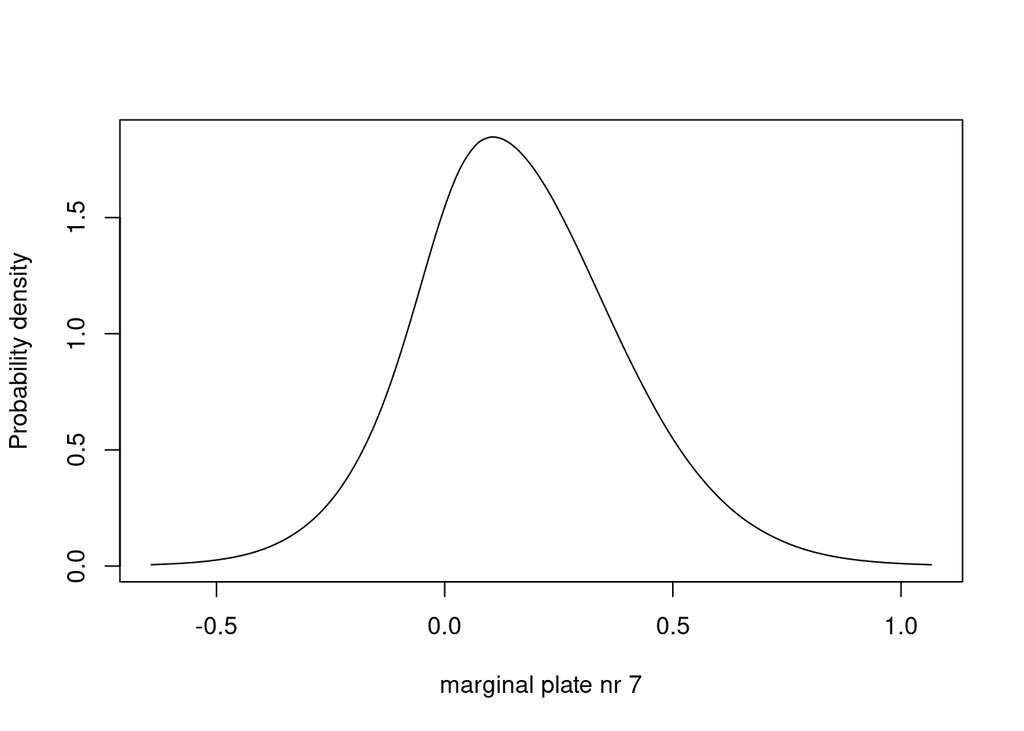

```r
m.plate.7 = inla.tmarginal(fun = function(x) x, marginal = res1$marginals.random$plate$index.7)
plot(m.plate.7, type="l", xlab = "marginal plate nr 7", ylab = "Probability density")
```

Here are different ways to get $\eta_7 = \beta_0 + \beta_1x_{17} + \beta_2x_{27} + v_7$

```r
res1$summary.linear.predictor$mean[7]
```

```
## [1] 0.8104081
```

```r
res1$summary.fixed$mean[1] + res1$summary.fixed$mean[2]*df[7,3] + res1$summary.fixed$mean[3]*df[7,4] + mean(res1$marginals.random$plate$index.7[,1])
```

```
## [1] 0.8140503
```

```r
res1$summary.fixed$mean[1] + res1$summary.fixed$mean[2]*df[7,3] + res1$summary.fixed$mean[3]*df[7,4] + res1$summary.random$plate$mean[7]
```

```
## [1] 0.8111263
```